# My Simple Logistic Regression

## Background

The data is from the 2018 Pyeongchang winter Olympic. Olympic happened the beginning of 2018, so i will use 2017 GDP data in this analysis. 2017 GDP 10th spot in the top10 country is Canada with 1652 billion GDP. I am curious what is the probability to get into top 10th GDP(above 1652 billion) countries based on number of Gold medal.

## Analysis

$$P(Y_i = 1|x_i) = \frac{e^{\beta_0+\beta_1 x_i}}{1+e^{\beta_0 + \beta_1 x_i}} = \pi_i$$

where for observation $i$:

- $Y_i = 1$ denotes when the country gdp reach 1652 billion
- $Y_i=0$ denotes when the country gdp can’t reach 1652 billion
- $x_i$ represents number of gold medal
- $\beta_1$ represents the effect of number of gold medal

<br >

Here is null and alternative hypothesis.

$$H_0: \beta_1 = 0 \\
H_a: \beta_1 \neq 0\\
a = 0.05$$

Logistic test :

```r
olympic.glm <- glm(GDP>1652 ~ Gold, data=olympic, family=binomial)
pander(summary(olympic.glm))
```

|  | Estimate | Std. Error | z value | Pr(>\|z\|) |
| --- | --- | --- | --- | --- |
| **(Intercept)** | -1.747 | 0.6372 | -2.741 | 0.006125 |
| **Gold** | 0.1943 | 0.1048 | 1.854 | 0.06368 |

(Dispersion parameter for binomial family taken to be 1 )

| Null deviance: | 34.16 on 28 degrees of freedom |
| --- | --- |
| Residual deviance: | 30.31 on 27 degrees of freedom |

<br > <br > The visualization of the model :

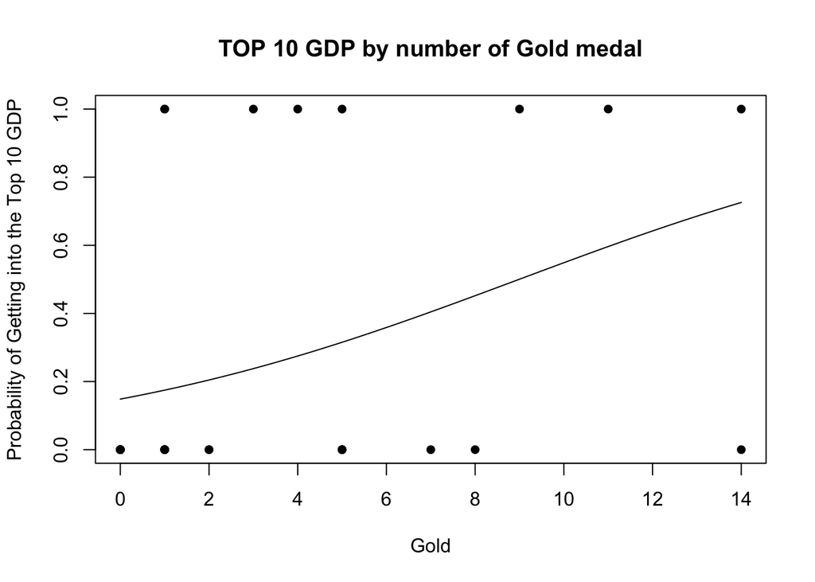

```r
plot(GDP>1652 ~ Gold, data=olympic, main="TOP 10 GDP by number of Gold medal", ylab = "Probability of Getting into the Top 10 GDP", pch=16)
curve(exp(-1.747+0.1943*x)/(1+exp(-1.747+0.1943*x)), add=TRUE)
```

Diagnosis of the model: (checking if the logistic test is a good fit for this data)

```r
pander(hoslem.test(olympic.glm$y, olympic.glm$fitted, g=5))
```

[output not shown]

## Interpretation

Since the P-value of logistic test is higher than significant level(a=0.05), we cannot predict GDP by number of gold medal. <br >However, if p-value is below than significant level, slope will be $1.2144606$. It means that number of gold medal increase by 1, the odds of the the country GDP being over 1652 increased by 21 percent.

```r
pander(predict(olympic.glm, data.frame(Gold=10), type='response'))
```

| 1 |
| --- |
| 0.5489 |

Note that for a 10 gold medal our model put the probability of a GDP 1652 billion at 0.5489.